None

# Challenge

In this week's challenge, you will model part of this simulated, small hydro-electric power station. In the frame below, note how clicking the "VALVE" button will open the "penstock valve" on the turbine and allow water to spin it. When the turbine shaft spins, electricity in the form of a DC voltage is delivered to a small cabin.

[interactive chart not shown]

This simulated power station also comes with a data recorder-- simply select the "REC" button to turn on the recording feature. When you are finished recording, un-select REC and a data file will be downloaded to your machine. Using the Jupyter file interface from the Reading 16 folder, you can upload your data file to the server for processing using MATLAB/Octave.

This small hydro station was inspired by the "micro turbines" you might find in developing countries or in small, rural cabin setups. An example of one such turbine design is shown in the video below. **Imagine what it would be like to be able to predict the behavior of this type of system, and design a good one without so much trial and error!** Learning to model turbines could allow you to do just that!

[video not shown]

In order to understand how a system like this must work, it is first necessary to realize that not only is energy *stored* in a system like this (just look at that turbine shaft spin and coast gradually to a stop when the valve is closed!) but energy is *converted* from one form to another!

In a hydro-electric power system, power begins as hydraulic or fluid power, $P\dot{\mathcal{V}}$. Then, the power from the fluid's flow is converted into rotational mechanical power, $T\Omega$, as the fluid pushes on the turbine blades, causing a torque on the blades relative to their spinning axis. Finally, this rotational mechanical power is converted to electrical power, $Vi$, by either an *alternator* (for AC power stations) or a *generator* (for DC power stations). The electrical power can then be sent for conversion, storage or use by a resistive load.

While most medium and large hydro power stations produce AC power like the type that is sent to your house (where the current direction reverses periodically as a sine wave), our simulated system produces DC power, which will provide a constant current in a constant direction at steady state. Car and camper systems are often DC, which makes it a good fit for our simulated rural power system.

In order for us to even begin to understand what is happening in a hydro power system, it is first necessary for us to understand: what does it mean for power (and thus energy) to be converted from one form to another? How can we model this? The key to answering this question is understanding yet another "idealized" element in the system dynamicist's toolbox: The power-converting transducer.

## Idealized Power-Converting Transducers

An idealized, power-converting transducer, like all of the other physical system elements we have studied, obeys the conservation of energy. However, like the other idealized element types we've talked about, the power-converting transducer only does "one job," and that is power conversion. Therefore, if something can be said to be adequately modeled as a power-converting transducer, it cannot store energy or transfer it to the system's surroundings. In other words, its first law of thermodynamics equation in power form looks like this: $$\require{cancel}$$ $$\cancel{\dot{E}} = \dot{W}_{in} - \dot{W}_{out} + \cancel{\dot{Q}_{in}} - \cancel{\dot{Q}_{out}}+\cancel{\dot{e}_{m,in}} - \cancel{\dot{E}_{m,out}}$$

Simplified, we find the fundamental equation that defines an idealized power-converting transducer:

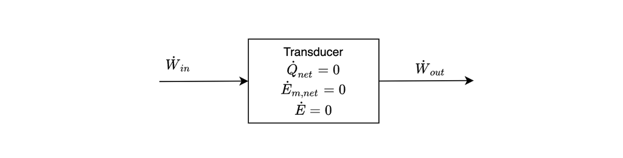

$$\dot{W}_{in} = \dot{W}_{out}$$

While this looks a bit like the equation we used to define a "node," for a transducer, $\dot{W}_{in}$ and $\dot{W}_{out}$ will always represent a change in the power variables from the "input" side to the "output" side of the element.

## Challenge Continued: No Idealized Power-Converting Transducers Actually Exist

Now, it is true that absolutely **no** such thing exists in the real world. But much like a node, the *idea* of an idealized transducer is useful for modeling, because the "non-idealities" (violations of the above form of the first law) associated with *real* transducers can usually be incorporated by including either energy-storing or energy-dissipating elements along with an ideal transducer. This is called the "lumped element modeling" approach, and while it isn't always appropriate, it is often a decent first approximation of reality.

While we could demonstrate how this is done by jumping right in to a discussion of fluid-mechanical or mechanical-electrical power convertors, it makes sense to begin with an even simpler example. Imagine you were to model the following system, consisting of a mass tied to a pulley with a very lightweight and very stiff string wrapped around it (no slip!). The pulley, which has rotational inertia $J$, is attached to ground with a bearing having approximately linear viscous damping with a damping coefficient $b$.

You scope your system's output as $\Omega$, and its input as the force of gravity acting on the mass, $mg$.

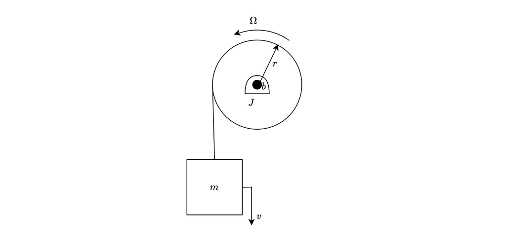

Making the typical assumptions we have made in the past about the first law of thermodynamics for the mass, the pulley's inertia, and the bearing connecting the pulley to ground, we might say that $\dot{W}_{out,m}$ for the mass is due to the tension in the string. In other words, $$\dot{W}_{out,m} = F_s v$$

Where $F_s$ is the string tension. We could then argue that the power *driving* the pulley and increasing its stored kinetic energy, $\dot{W}_{in,p}$, could be written as:

$$\dot{W}_{in,p} = T_s \Omega$$

Where $T_s$ is the *torque generated by* the tension in the string. Making the assumption that no power is lost to the system's surroundings by the string itself, we could say that:

$$\dot{W}_{in,p} = \dot{W}_{out,m}$$

Drawing this relationship as if it were a distinct element in our system, we might draw the *transducer's* energetic diagram to look like this:

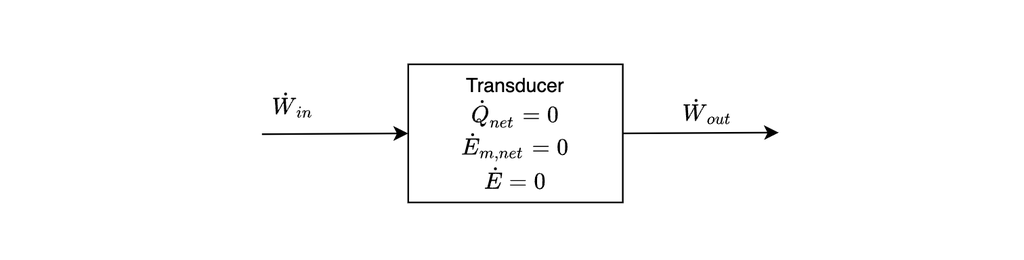

You could insert this transducer in between the "real" pulley, which has inertia, and the "real" mass. It represents how the pulley would function if it had no inertia, and was not attached to the wall via a viscous damper. Substituting in our power terms, we could re-write the idealized transducer equation as:

$$T_s \Omega = F_s v$$

But how does this help us with model building? The two types of power are different, and although we can faithfully report that they are equal, we need a way to relate the force and velocity going in to the torque and angular velocity going out. **Unlike a node**, where (if it only had one source of power going in, and one going out) we could simply equate the through and across type power variables, here the power has a different form on the input vs. the output side... **so we need equations to tell us about the physics that govern how the power is converted.**

**Remember that the first law of thermodynamics does not tell us *how.* It simply tells us what the balance of energy must be**.

In the case of the pulley, we can develop a relationship between the torque exerted by the string on the pulley and the force in the string. By Newton's laws, we know that the torque on the pulley from the string is related to the string's tension as follows:

$$T_s = F_s r$$

We also know, given our geometric definition of positive $\Omega$ and positive $v$, that the velocity of the mass and the angular velocity of the pulley are related:

$$\Omega r = v$$

Now that we have two relationships that relate the two power variables on each "side" of the idealized transducer, we can link the two types of power through the pulley's radius $r$!! This is what would allow us to complete our model of the pulley system. Note that if I substitute the geometric relationship $v = \Omega r$ into the energy conservation equation for the ideal transducer, I would get:

$$T_s \Omega = F_s r \Omega$$

Which reduces to the torque/force relationship $T_s = F_s r$. Similarly, if I were to substitute the torque equivalence $T_s = F_s r$ into the original energy balance for the idealized transducer, I would get:

$$F_s r \Omega = F_s v$$

Which reduces to the geometric relationship $v = \Omega r$.

**Every Transducer has two equations to describe how it converts power-- one linking each input power variable to each output power variable.**

If we were to draw an equivalent circuit for the pulley system, we could represent the transducer with any symbol that shows us a "bridge" between two different circuits, where the across and through type variables may have different units. One possible such symbol is shown below:

## Representing Power-Converting Transducers in Equivalent Circuits

There is no grand universal symbol used for representing power-converting transducers in equivalent circuit diagrams. We will simply pick a symbol with the knowledge that others are possible, but all must have four "ports" in order to connect two equivalent circuits that show two different *types* of power flow.

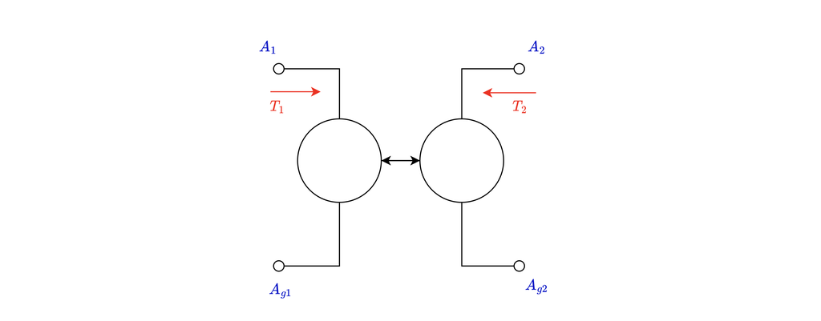

In this diagram, $A_1$ and $T_1$ represent the across and through type variables that drive the transducer ($\dot{W}_{in}$) before conversion of power, while $A_2$ and $T_2$ represent the across and through type variables generated by the transducer as it converts the input power into a different form. The double-ended arrow between the two circular "circuit elements" indicates that power is equal on each side, even though there is not a physical "wire" connecting them.

You can include a power-converting transducer in your equivalent circuit just like any other element. As you construct an equivalent circuit, you will be looking for nodes of constant A-type power in your system in order to draw your equivalent circuit. For example, you may find that your system has both a velocity and a pressure that are important, because your system converts between fluid and mechanical power. Because these two variables represent different *types* of power, an idealized transducer is a way to represent the connection between those two disparate nodes.

Take care to represent the reference variable (0 or "ground") for each power type separately in your circuit, and **always ensure that on any one side of a power-converting transducer, you only have one type of power in your circuit**. For example, you would not want a fluid capacitor and a mechanical damper to exist on one side of a fluid-to-mechanical transducer. **Keep power types consistent between transducers in your circuit.**

## Challenge in Practice: representing a pulley as an equivalent circuit with a transducer

An example of using the above symbol for a transducer to represent power conversion in our pulley system is shown below:

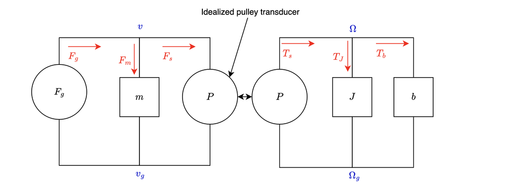

Note that in this equivalent circuit, the left-hand side has an across-type power variable of velocity (m/s), while the right side has an across-type variable of angular velocity (rad/s). Linking the two circuits with the element labeled "P," which has 4 "ports" vs. the other elements' 2, allows us to bridge these two equivalent circuits in a way that preserves the utility of continuity and compatibility for studying how power flows between elements.

Pulleys, although simplistic, are common... they also aren't the only rotational-translational mechanical transducers. A summary is given below.

### Idealized Rotational Mechanical to Translational Mechanical Power Transducers

Wheels, Pulleys, and rack-and-pinion gears that represent contact between a translating body and a rotating body can be modeled as idealized power-converting transducers as long as there is no slip at the point of contact. Examples are shown below:

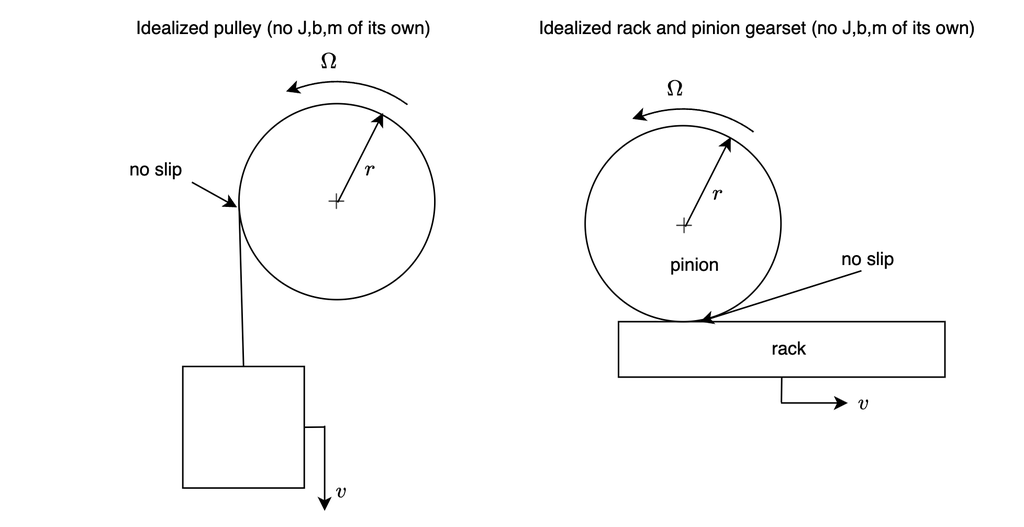

For these idealized elements, The first law of thermodynamics in power form can be written:

$$F v = T \Omega$$

and the power variables between each side of the idealized transducer can be linked by the following two equations:

$$Fr = T$$$$r\Omega = v$$

Signs may have to be adjusted given positive directions defined by the engineer. **Inertias and damping effects must be included as separate elements by the engineer if they are determined to be significant in the context of the system**.

## Challenge in practice: converting between mechanical and electrical power

You might be asking: "how does a pulley help me with this notebook's challenge?" The pulley is an example of a transducer that uses no "new" physics knowledge to explain how power is converted from one form to another. Now that we're familiar with the idea, let's take a look at something a little more relevant to our current project.

Because DC generators and DC motors are functionally the same (one converts mechanical->electrical power and the other electrical -> mechanical power), we will spend a moment talking about electric motors and how idealized transducers fit in to models of their operation.

The basics of how a permanent-magnet, DC electric motor are given in the short video below:

[video not shown]

As the video explains, [Lorentz's Law](https://en.wikipedia.org/wiki/Lorentz_force), which was based on **empirical observations**, relates the current in a wire to an *induced magnetic field*. Weirdly, wherever current flows, a magnetic field is generated.

It is also true that by [Faraday's Law of Induction](https://en.wikipedia.org/wiki/Faraday's_law_of_induction), which was **also based on empirical observations**, changing the magnetic field around a coil of wire (by, say, swinging magnets around it) "induces" a voltage in that coil.

These two principles provide the "physical linkage" that describes the power conversion in a DC motor, which is often modeled *in part* by an idealized electrical to rotational mechanical transducer. While it is possible to use the original form of these laws to derive relationships relevant for a particular DC motor, it is usually not done. Often, motors are sold with a table of empirically-derived parameters that give us all of the information we need.

For instance, motors are often advertised as having a particular "torque constant" which is an empirical parameter relating current through the motor to torque:

$$T = k_t i$$

Motors are usually also sold with a specification for the "voltage constant" which specifies the *voltage drop* across the motor terminals as a function of the motor's speed. This is also usually an empirical parameter. Assume, in this equation, that the motor's positive terminal is attached to "node 1" and its negative terminal is attached to "node 2."

$$V_{12} = k_v \Omega$$

If the motor's conversion of power could be modeled as an ideal transducer, we would need to be able to write its first law of thermodynamics equation as:

$$T \Omega = V_{12} i$$

Where $V_{12}$ represents the voltage drop across the motor's terminals.

These two relationships **must be** consistent with the first law of thermodynamics. They are, but only if $k_v = k_t = k$. Solving each equation for the motor constant $k$ yields:

$$k = \frac{T}{i} = \frac{{V}_{12}}{\Omega}$$

Cross-multiplying these two equations allows us to recover our first law equation for an ideal transducer, which is a relief!

### Idealized Electrical- Rotational Mechanical Power Transducers

If their armature (coils of wire) do not store significant magnetic field energy, DC motors and DC generators are sometimes modeled as idealized transducers with added armature resistance on the electrical side along with motor shaft inertia and viscous damping on the mechanical side. An example is shown below. The motor model's physical layout of idealized components is shown on the left, and the total equivalent circuit is shown on the right.

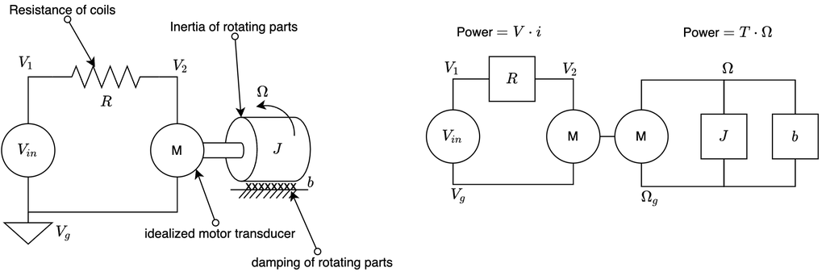

Notice that the left half of the equivalent circuit shows power transfer as the product of voltage (across) and current (through), while the right side shows power transfer as the product of angular velocity (across) and torque (through). The idealized transducer encompasses the motor's conversion of electrical to rotational mechanical power. Assuming no significant heat transfer, mass transfer, or energy storage, the idealized part of the motor has a first law of thermodynamics equation that can be written:

$$V_{2g} i = T\Omega$$

With the following two equations relating torque with current and angular velocity with voltage drop:

$$T = k i $$$$V_{2g} = k \Omega$$

Now that we have an understanding of how electrical and rotational mechanical power can be linked using a motor or generator (depending on who is driving whom!), let's move on and discuss the final type of power conversion necessary to understand the hydroelectric power station.